# Data Visualization Lab - Key

# Part 1

Load the packages.

```r
library(tidyverse)
```

Read in the Bike Lanes Dataset using the `read_csv` function with the following link: http://jhudatascience.org/intro_to_r/data/Bike_Lanes.csv

Assign the data to an object called `bike`.

Then, use the provided code to compute a data frame `bike_agg` with aggregate summary of bike lanes: average length of lanes (`lane_avg_length`) for each year (`dateInstalled`).

```r
bike <- read_csv(file = "http://jhudatascience.org/intro_to_r/data/Bike_Lanes.csv")
bike_agg <- bike %>%
  # filter data to keep only these observations for which year is non-0
  filter(dateInstalled != 0) %>%
  group_by(dateInstalled) %>%
  summarise(lane_avg_length = mean(length))

bike_agg
```

```
## # A tibble: 8 × 2
##   dateInstalled lane_avg_length
##           <dbl>           <dbl>
## 1          2006           1469.
## 2          2007            310.
## 3          2008            249.
## 4          2009            407.
## 5          2010            246.
## 6          2011            233.
## 7          2012            271.
## 8          2013            290.
```

### 1.1

Use the object you just created (`bike_agg`) and the `ggplot2` package to make plot of average length of lanes (`lane_avg_length`; y-axis) for each year (`dateInstalled`; x-axis). You can use lines layer (`+ geom_line()`) or points layer (`+ geom_point()`), or both!

Assign the plot to variable `my_plot`. Type `my_plot` in the console to have it displayed.

```
# General format
ggplot(???, aes(x = ???, y = ???)) +
  ??? +
  ???
```

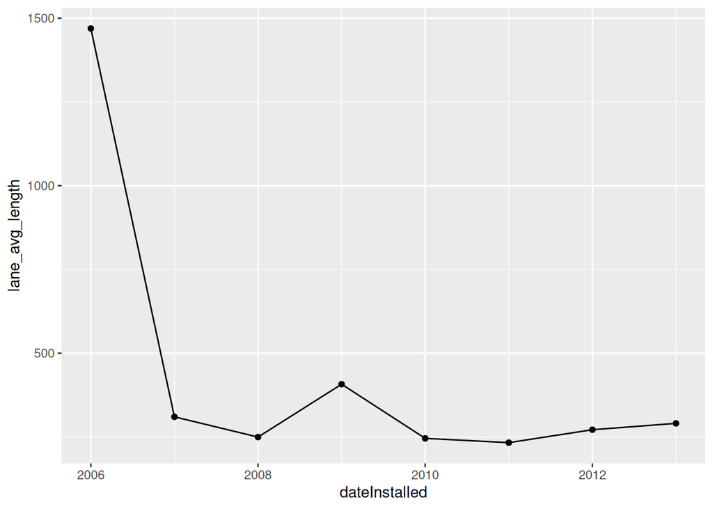

```r
my_plot <-
  ggplot(bike_agg, aes(x = dateInstalled, y = lane_avg_length)) +
  geom_line() +
  geom_point()

my_plot
```

### 1.2

“Update” your plot by adding a title and changing the x and y axis titles. (Hint: use the `labs` function.)

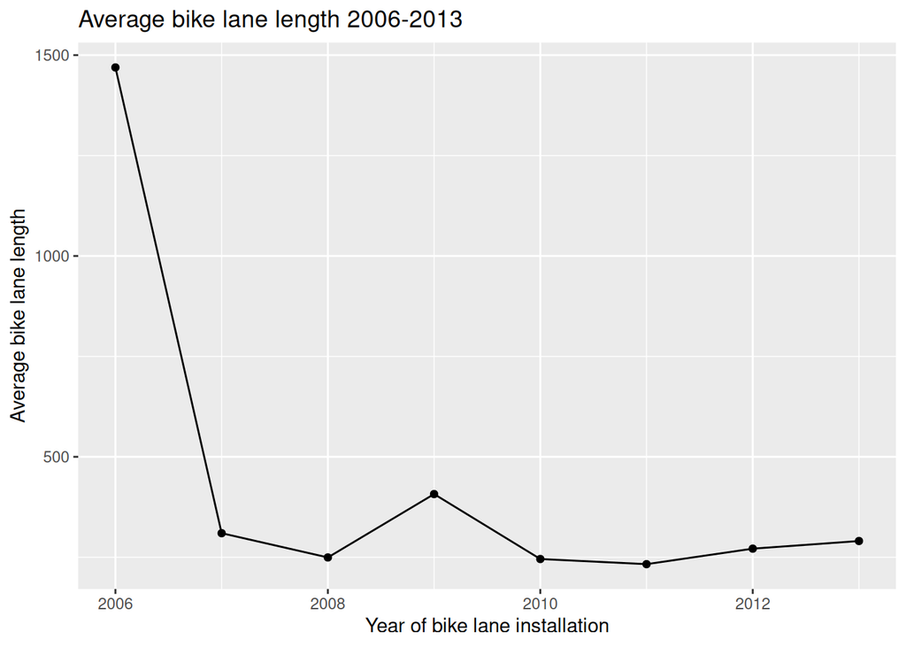

```r
my_plot <- my_plot +
  labs(
    x = "Year of bike lane installation",
    y = "Average bike lane length",
    title = "Average bike lane length 2006-2013"
  )

my_plot
```

### 1.3

Use the `scale_x_continuous()` function to plot the x axis with the following breaks `c(2006, 2007, 2008, 2009, 2010, 2011, 2012, 2013)`.

```
# General format
my_plot<- my_plot +
  scale_x_continuous(breaks = ?????)
```

```r
my_plot <- my_plot +
  scale_x_continuous(
    breaks = c(2006, 2007, 2008, 2009, 2010, 2011, 2012, 2013)
  )

my_plot
```

[output not shown]

```r
my_plot <- my_plot +
  scale_x_continuous(
    breaks = seq(from = 2006, to = 2013, by = 1)
  )
my_plot
```

[output not shown]

### 1.4

Observe several different versions of the plot by displaying `my_plot` while adding a different “theme” to it.

```
# General format
my_plot + theme_bw()
```

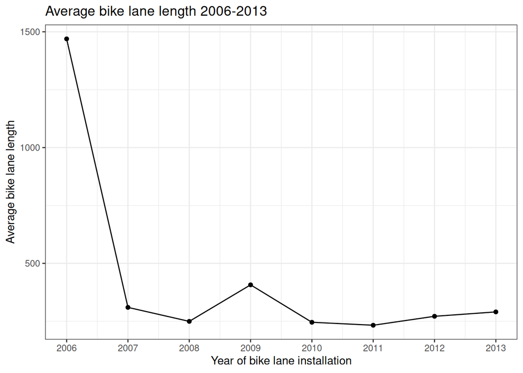

```r
my_plot + theme_bw()
```

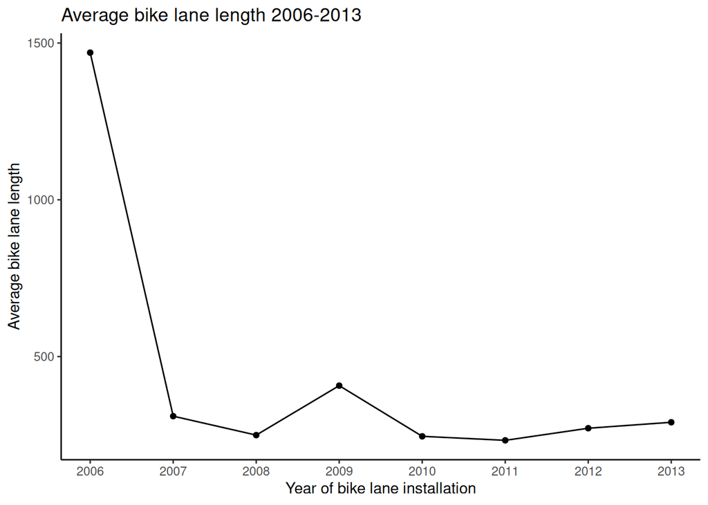

```r
my_plot + theme_classic()
```

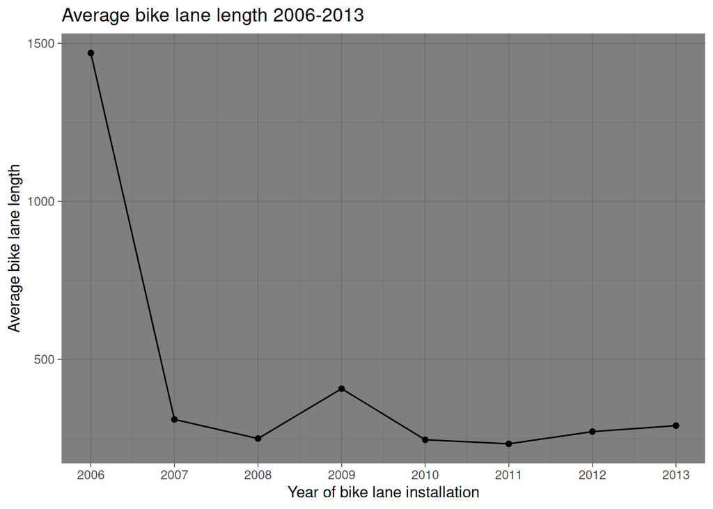

```r
my_plot + theme_dark()
```

```r
my_plot + theme_gray()
```

[output not shown]

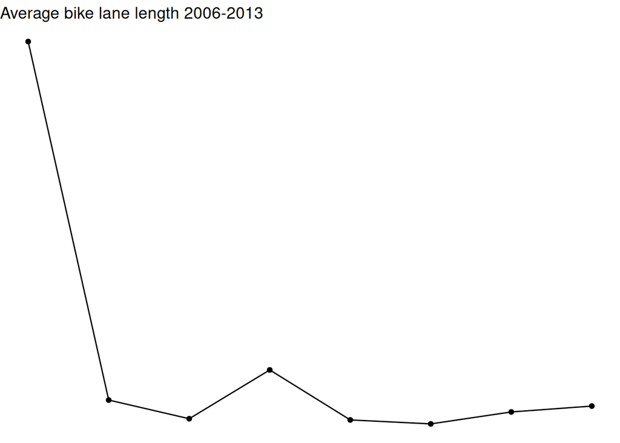

```r
my_plot + theme_void()
```

# Practice on Your Own!

### P.1

Create a boxplot (with the `geom_boxplot()` function) using the `Orange` data, where `Tree` is plotted on the x axis and `circumference` is plotted on the y axis.

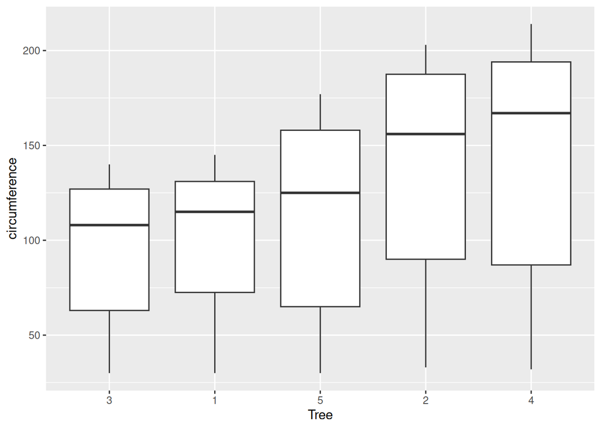

```r
Orange %>%
  ggplot(aes(x = Tree, y = circumference)) +
  geom_boxplot()
```

Notice how the trees are ordered. We will learn more about this soon!

# Part 2

### 2.1

Use the provided code to compute a data frame `bike_agg_2` with aggregate summary of bike lanes: number of lanes (`lane_count`) – separately for each year (`dateInstalled`) and for each lane type.

```r
bike_agg_2 <- bike %>%
  filter(dateInstalled != 0) %>%
  group_by(dateInstalled, type) %>%
  summarise(lane_count = n())
bike_agg_2
```

```
## # A tibble: 22 × 3
## # Groups:   dateInstalled [8]
##    dateInstalled type            lane_count
##            <dbl> <chr>                <int>
##  1          2006 BIKE LANE                2
##  2          2007 BIKE LANE              127
##  3          2007 SHARROW                 95
##  4          2007 SIGNED ROUTE           146
##  5          2008 BIKE LANE               55
##  6          2008 SHARROW                148
##  7          2008 SIDEPATH                 3
##  8          2009 BIKE LANE               46
##  9          2009 SHARED BUS BIKE         30
## 10          2009 SHARROW                 10
## # ℹ 12 more rows
```

### 2.2

Use `ggplot2` package to make a plot showing trajectories of number of lanes (`lane_count`; y-axis) over year (`dateInstalled`; x-axis), where each bike line type has a different color (hint: use `color = type` in mapping).

```
# General format
ggplot(???, aes(
  x = ???,
  y = ???,
  color = ???
)) +
  geom_line() +
  geom_point()
```

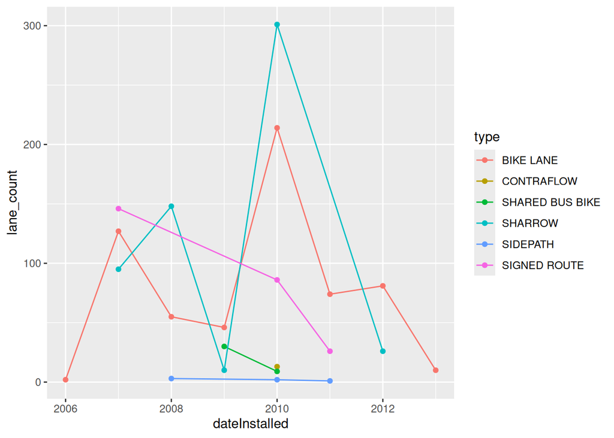

```r
ggplot(bike_agg_2, aes(
  x = dateInstalled,
  y = lane_count,
  color = type
)) +
  geom_line() +
  geom_point()
```

### 2.3

Redo the above plot by adding a faceting (`+ facet_wrap( ~ type, ncol = 3)`) to have data for each bike line type in a separate plot panel.

(You may see `geom_path: Each group consists of only one observation. Do you need to adjust the group aesthetic?` warning as some bike lane types will have only 1 point plotted while trying to plot a line). Assign the new plot as an object called `facet_plot`.

Try adjusting the number of columns in the `facet_wrap` to see how this changes the plot.

```
## `geom_line()`: Each group consists of only one observation.
## ℹ Do you need to adjust the group aesthetic?
```

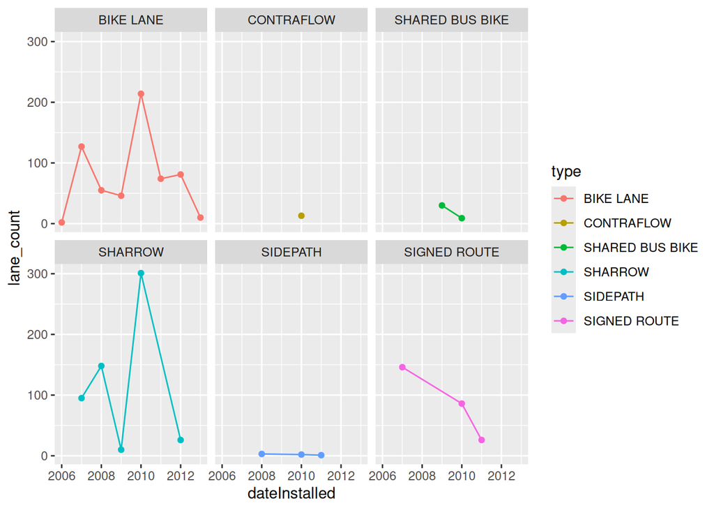

```r
facet_plot <- ggplot(bike_agg_2, aes(
  x = dateInstalled,
  y = lane_count,
  color = type
)) +
  geom_line() +
  geom_point() +
  facet_wrap(~type, ncol = 3)

facet_plot
```

### 2.4

Observe what happens when you remove either `geom_line()` OR `geom_point()` from one of your plots above.

```r
# These elements are removed from the plot, like layers
```

# Practice on Your Own!

### P.2

Modify `facet_plot` to remove the legend (hint use `theme()` and the `legend.position` argument) and change the names of the axis titles to be “Number of bike lanes” for the y axis and “Date bike lane was installed” for the x axis.

```
## `geom_line()`: Each group consists of only one observation.
## ℹ Do you need to adjust the group aesthetic?
```

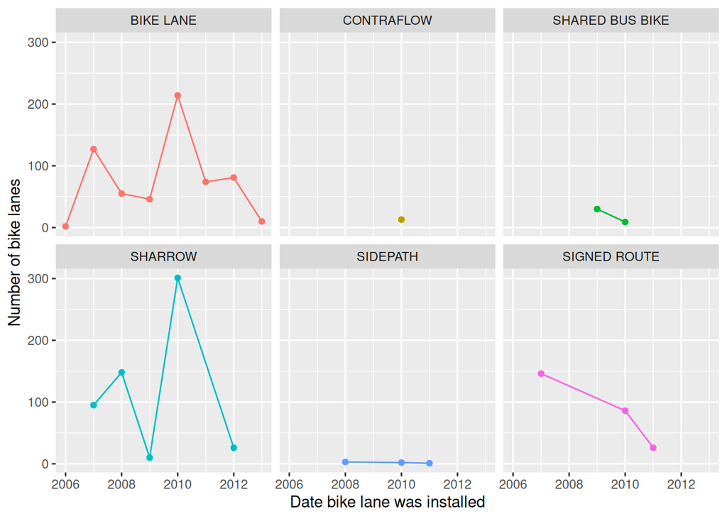

```r
facet_plot <- facet_plot +
  theme(legend.position = "none") +
  labs(
    y = "Number of bike lanes",
    x = "Date bike lane was installed"
  )

facet_plot
```

### P.3

Modify `facet_plot` one more time with a fun theme! Look into the [ThemePark package](https://github.com/MatthewBJane/ThemePark) It has lots of fun themes! Try one out! Remember you will need to install it using `remotes::install_github("MatthewBJane/ThemePark")`and load in the library.

```
## `geom_line()`: Each group consists of only one observation.
## ℹ Do you need to adjust the group aesthetic?
```

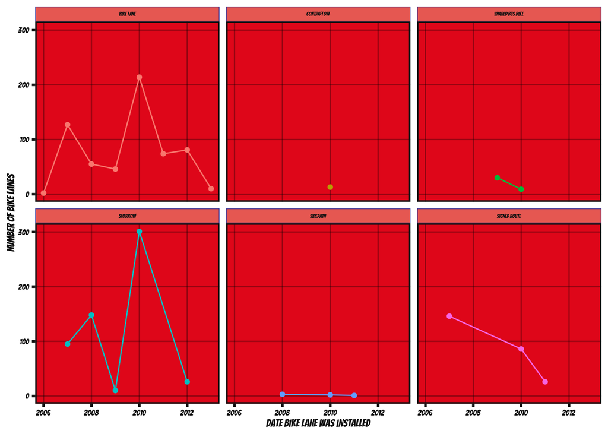

```r
# remotes::install_github("MatthewBJane/ThemePark")
library(ThemePark)

facet_plot + theme_spiderman()
```